# **Panorama da inflação**

# IPCA

|  | 12/2007 | 11/2008 | 12/2008 |
| --- | --- | --- | --- |
| Variação mensal | 0.74% | 0.36% | 0.28% |
| Variação acumulada no ano | 4.46% | 5.61% | 5.9% |
| Variação acumulada em 12 meses | 4.46% | 6.39% | 5.9% |

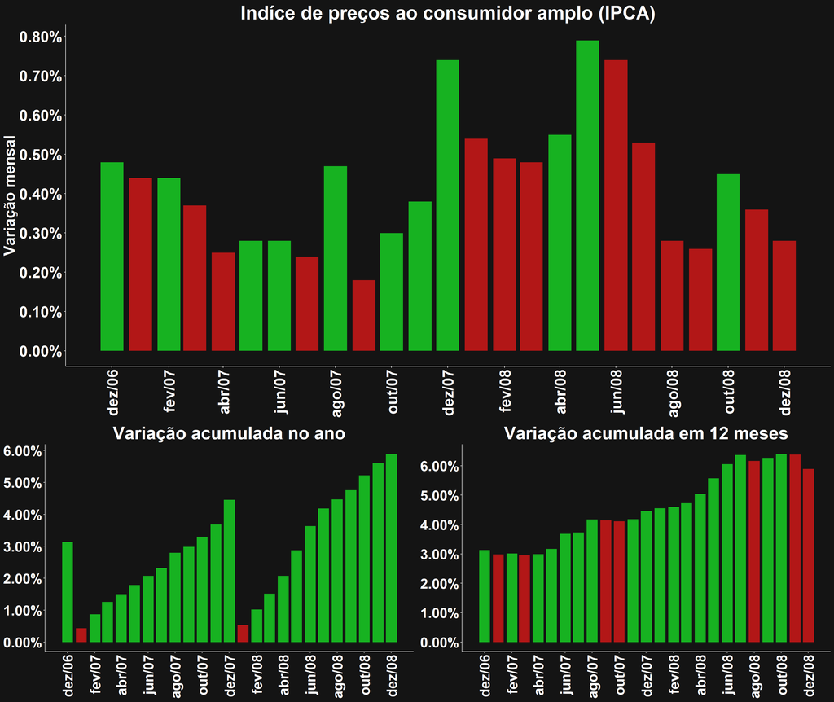

Os grupos que tiveram maior resultado positivo foram Vestuário (0.99%) e Despesas pessoais (0.59%), e negativo Artigos de residência (-0.04%) e Transportes (-0.03%).

|  | Variação mensal | Variação acumulada no ano | Peso mensal |
| --- | --- | --- | --- |
| Alimentação e bebidas | 0.36% | 11.12% | 22.76% |
| Habitação | 0.28% | 5.09% | 13.16% |
| Artigos de residência | -0.04% | 1.99% | 4.26% |
| Vestuário | 0.99% | 7.3% | 6.58% |
| Transportes | -0.03% | 2.32% | 19.75% |
| Saúde e cuidados pessoais | 0.32% | 5.72% | 10.75% |
| Despesas pessoais | 0.59% | 7.35% | 9.83% |
| Educação | 0.08% | 4.58% | 6.95% |
| Comunicação | 0% | 1.79% | 5.96% |

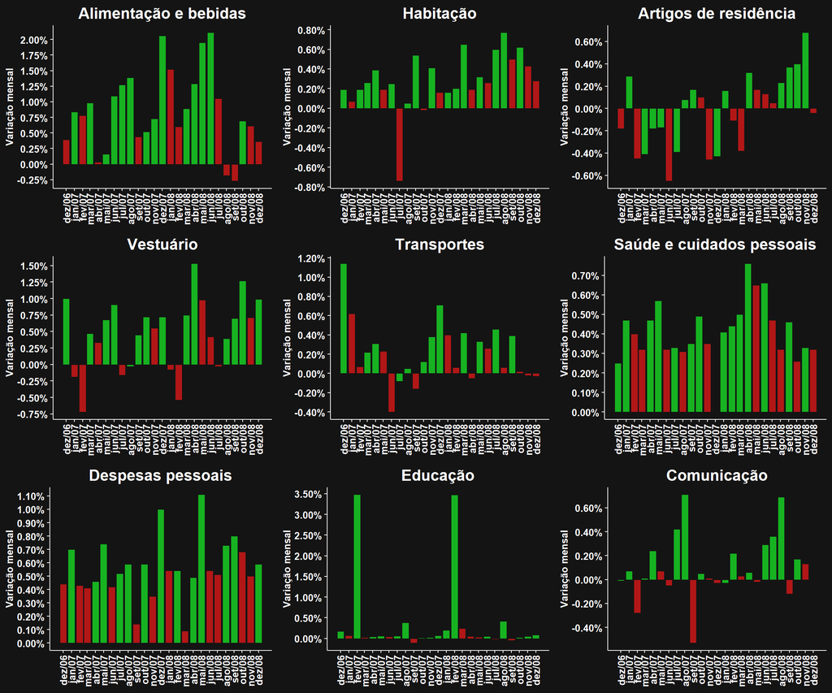

A nível de sub-itens os que mais influenciaram positivamente no resultado em relação ao seu peso foram Tomate (34.11%%) e Refeição (0.98%%), e negativamente Feijão - carioca (rajado)) (-19.02%%) e Automóvel novo (-1.99%%).

|  | Variação mensal | Variação acumulada no ano | Peso mensal |
| --- | --- | --- | --- |
| Tomate | 34.11% | 108.3% | 0.17% |
| Refeição | 0.98% | 14.46% | 4.1% |
| Ônibus urbano | 0.89% | 3.07% | 3.66% |
| Empregado doméstico | 0.88% | 11.04% | 3.21% |

|  | Variação mensal | Variação acumulada no ano | Peso mensal |
| --- | --- | --- | --- |
| Automóvel novo | -1.99% | -2.25% | 2.76% |
| Feijão - carioca (rajado)) | -19.02% | -29.49% | 0.31% |
| Automóvel usado | -2.76% | -4.32% | 1.52% |
| Óleo de soja | -4.38% | 4.26% | 0.28% |

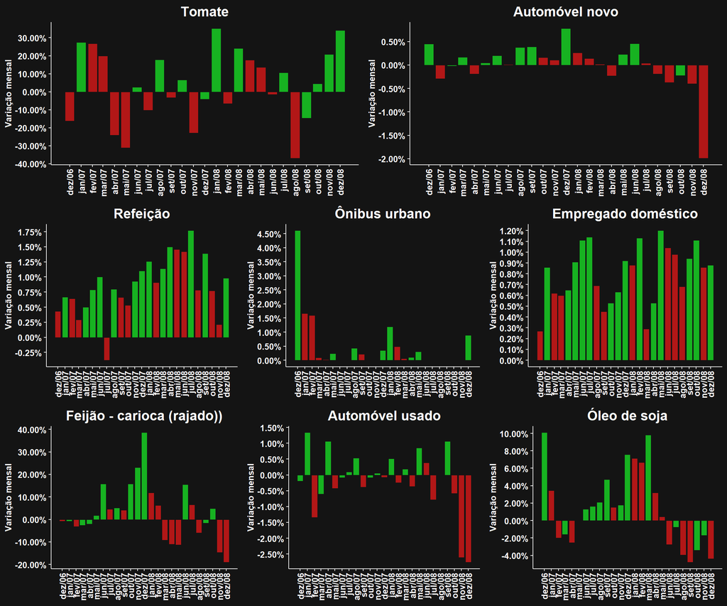

# INPC

|  | 12/2007 | 11/2008 | 12/2008 |
| --- | --- | --- | --- |
| Variação mensal | 0.97% | 0.38% | 0.29% |
| Variação acumulada no ano | 5.16% | 6.17% | 6.48% |
| Variação acumulada em 12 meses | 5.16% | 7.2% | 6.48% |

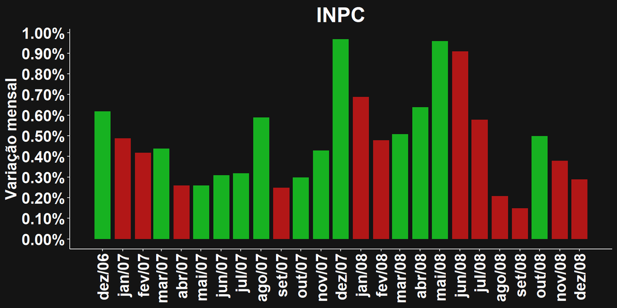

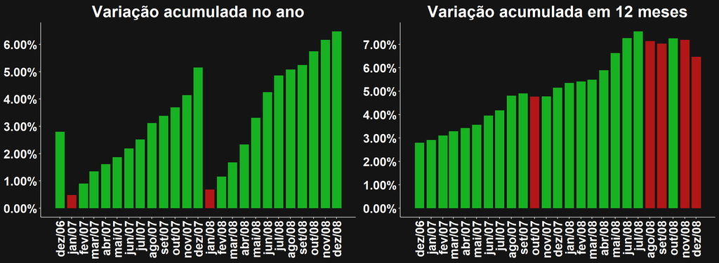

# IGP-M

O Indíce Geral de Preços de Mercado (IGP-M) variou -0.13% em dezembro, valor inferior ao mesmo período do ano anterior quando apresentou uma taxa de 1.76%. Com esse resultado o indíce acumula no ano uma variação positiva de 8.62%, e em 12 meses uma variação positiva de 9.81%.

|  | 12/2007 | 11/2008 | 12/2008 |
| --- | --- | --- | --- |
| Variação mensal | 1.76% | 0.38% | -0.13% |
| Variação acumulada no ano | 7.21% | 8.76% | 8.62% |
| Variação acumulada em 12 meses | 7.75% | 11.88% | 9.81% |

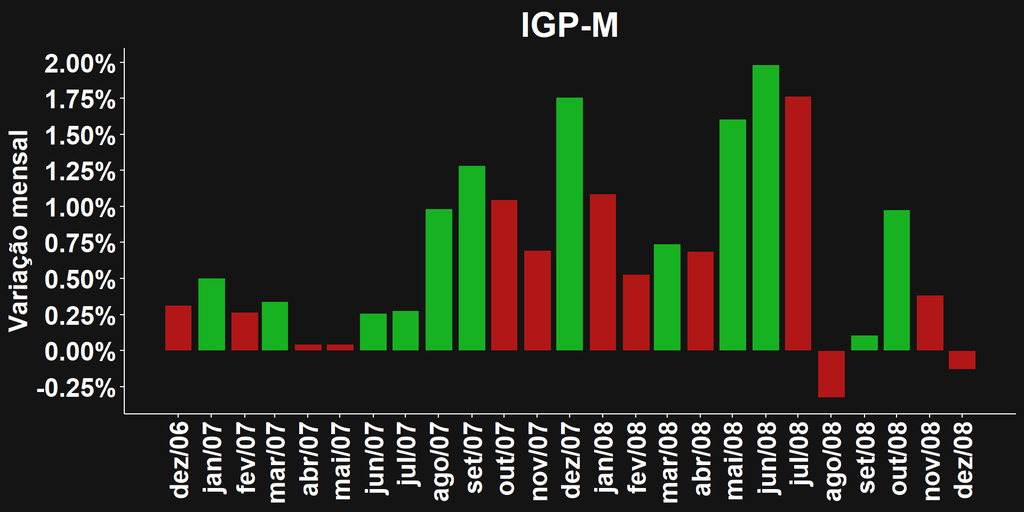

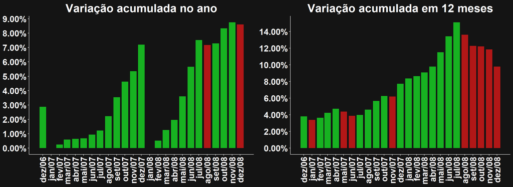